# Module 7: Heteroskedasticity; ARCH, GARCH and SVMs

## Learning outcomes

- Understand how to fit ARCH, GARCH and SVM models in JAGS
- Know how to check assumptions for these methods
- Know how to perform cross-validation as an alternative to model selection
- Know the basics of forecast calibration and scoring rules
- Understand how to create forecasts with JAGS via the NA method

Relevant JAGS file:

```
jags_ARCH.R
jags_GARCH.R
jags_SVM.R
```

## General principles of models for changing variance

- So far we have looked at models where the mean changes but the variance is constant: \[y_t \sim N(\mu_t, \sigma^2)\]
- In this module we look at methods where instead: \[y_t \sim N(\alpha, \sigma_t^2)\]
- These are:
- Autoregressive Conditional Heteroskedasticity (ARCH)
- Generalised Autoregressive Conditional Heteroskedasticity (ARCH)
- Stochastic Volatility Models (SVM)

## Extension 1: ARCH

- An ARCH(1) Model has the form: \[\sigma_t^2 = \gamma_0 + \gamma_1 \epsilon_{t-1}^2\] where \(\epsilon_{t}\) is the residual, just like an MA model
- Note that \(\epsilon_t = y_t - \alpha\) so the above can be re-written as: \[\sigma_t^2 = \gamma_0 + \gamma_1 (y_{t-1} - \alpha)^2\]
- The variance at time \(t\) thus depends on the previous value of the series (hence the autoregressive in the name)
- The residual needs to be squared to keep the variance positive.
- The parameters \(\gamma_0\) and \(\gamma_1\) also need to be positive, and usually \(\gamma_1 \sim U(0,1)\)

## JAGS code for ARCH models

```r
model_code = '
model
{
  # Likelihood
  for (t in 1:T) {
    y[t] ~ dnorm(alpha, tau[t])
    tau[t] <- 1/pow(sigma[t], 2)
  }
  sigma[1] ~ dunif(0, 10)
  for(t in 2:T) {
    sigma[t] <- sqrt( gamma_1 + gamma_2 * pow(y[t-1] - alpha, 2) )
  }

  # Priors
  alpha ~ dnorm(0.0, 0.01)
  gamma_1 ~ dunif(0, 10)
  gamma_2 ~ dunif(0, 1)
}
'
```

## Example: ice core data

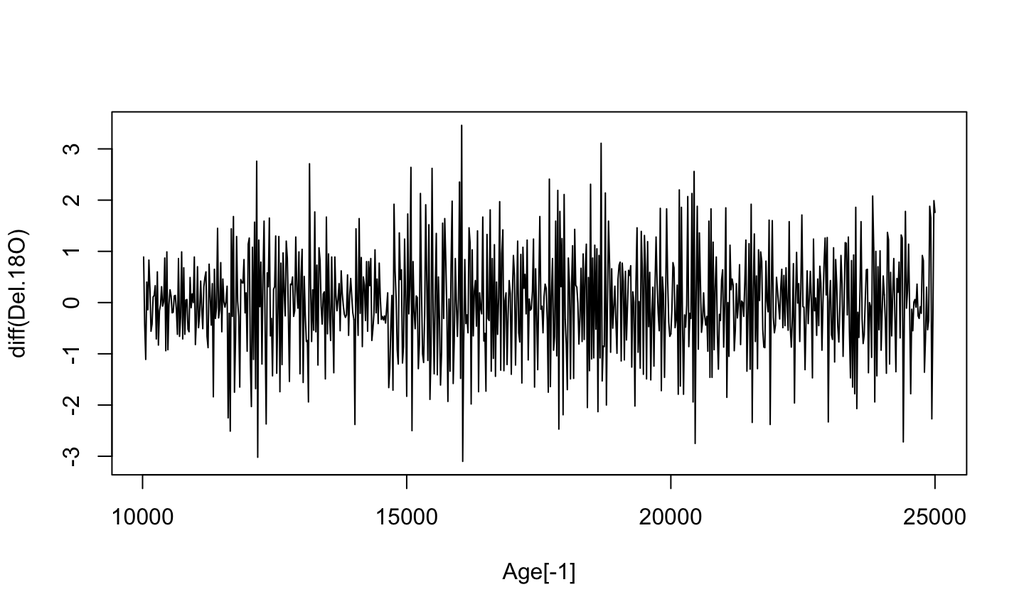

```r
with(ice2,plot(Age[-1],diff(Del.18O),type='l'))
```

## Example: ice core output

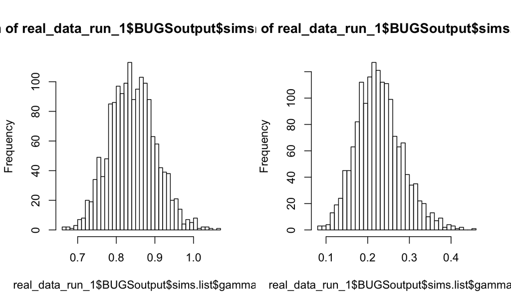

```r
par(mfrow=c(1,2))
hist(real_data_run_1$BUGSoutput$sims.list$gamma_1, breaks=30)
hist(real_data_run_1$BUGSoutput$sims.list$gamma_2, breaks=30)
```

## Example: posterior standard deviations

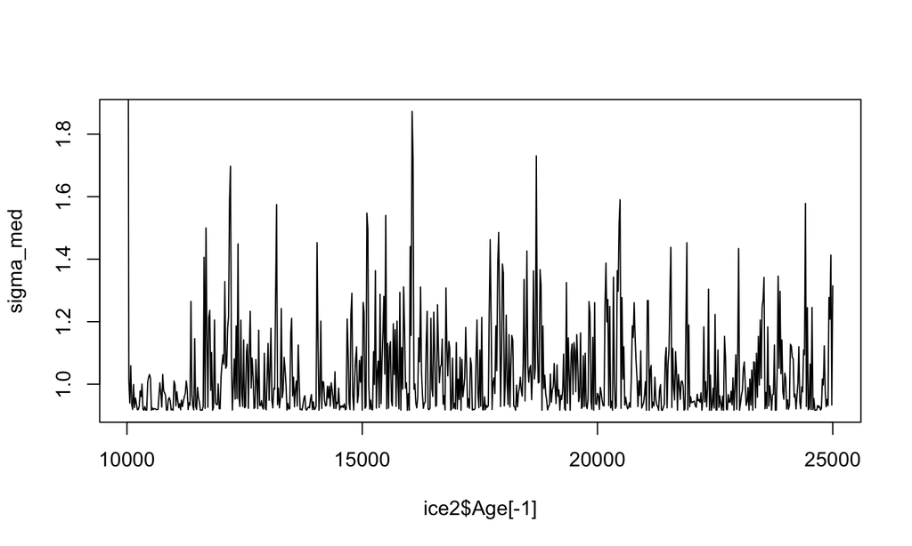

```r
sigma_med = apply(real_data_run_1$BUGSoutput$sims.list$sigma,2,'quantile',0.5)
plot(ice2$Age[-1],sigma_med,type='l',ylim=range(c(sigma_med[-1])))
```

## Example of using the GARCH(1,1) model

```r
model_code = '
model
{
  # Likelihood
  for (t in 1:T) {
    y[t] ~ dnorm(alpha, tau[t])
    tau[t] <- 1/pow(sigma[t], 2)
  }
  sigma[1] ~ dunif(0,10)
  for(t in 2:T) {
    sigma[t] <- sqrt( gamma_1 + gamma_2 * pow(y[t-1] - alpha, 2) + gamma_3 * pow(sigma[t-1], 2) )
  }

  # Priors
  alpha ~ dnorm(0.0, 0.01)
  gamma_1 ~ dunif(0, 10)
  gamma_2 ~ dunif(0, 1)
  gamma_3 ~ dunif(0, 1)
}
'
```

## Using the ice core data again

Have a look at the ARCH parameters;

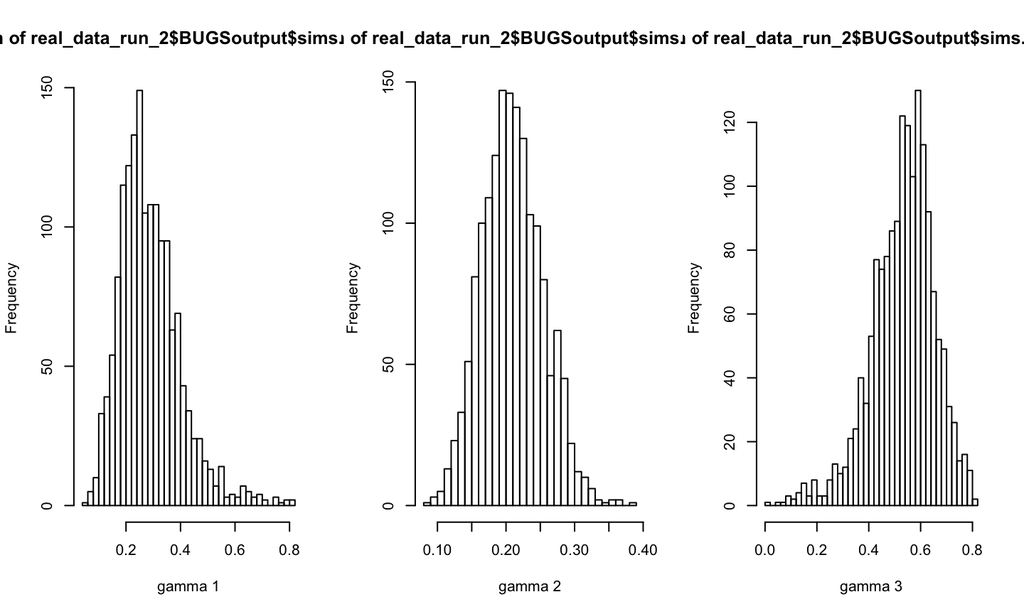

```r
par(mfrow=c(1,3))
hist(real_data_run_2$BUGSoutput$sims.list$gamma_1, breaks=30, xlab = 'gamma 1')
hist(real_data_run_2$BUGSoutput$sims.list$gamma_2, breaks=30, xlab = 'gamma 2')
hist(real_data_run_2$BUGSoutput$sims.list$gamma_3, breaks=30, xlab = 'gamma 3')
```

## Posterior median standard deviation

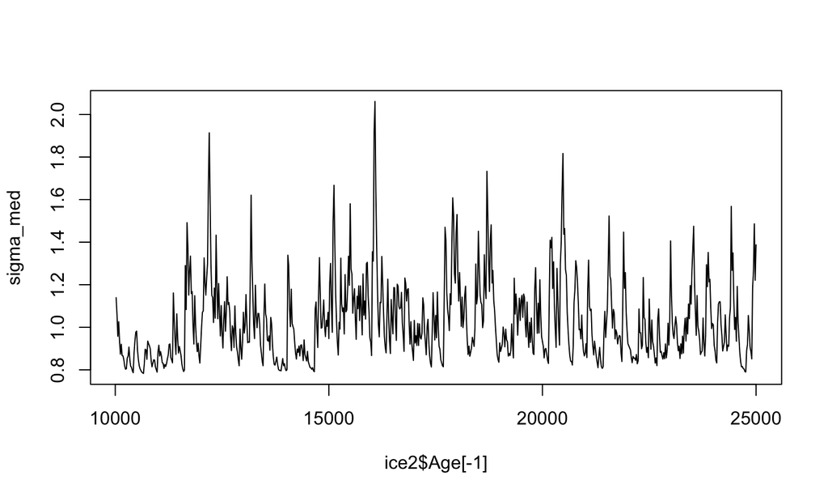

```r
sigma_med = apply(real_data_run_2$BUGSoutput$sims.list$sigma, 2, 'quantile', 0.5)
plot(ice2$Age[-1], sigma_med, type='l', ylim=range(c(sigma_med)))
```

## Compare with DIC

```
## Inference for Bugs model at "5", fit using jags,
##  4 chains, each with 1000 iterations (first 200 discarded), n.thin = 2
##  n.sims = 1600 iterations saved
##             mu.vect sd.vect     2.5%      25%      50%      75%    97.5%
## alpha         0.004   0.033   -0.065   -0.018    0.005    0.026    0.066
## gamma_1       0.842   0.060    0.728    0.800    0.840    0.882    0.961
## gamma_2       0.228   0.055    0.130    0.189    0.225    0.261    0.351
## sigma[1]      3.524   2.527    0.551    1.429    2.720    5.217    9.313
## sigma[2]      1.010   0.028    0.956    0.991    1.010    1.029    1.068
## sigma[3]      0.940   0.030    0.883    0.920    0.940    0.961    0.999
## sigma[4]      1.060   0.032    0.998    1.038    1.059    1.082    1.126
## sigma[5]      0.937   0.031    0.878    0.916    0.936    0.957    0.997
## sigma[6]      0.920   0.032    0.857    0.897    0.919    0.941    0.983
## sigma[7]      0.999   0.028    0.944    0.980    0.999    1.017    1.057
## sigma[8]      0.926   0.032    0.866    0.905    0.925    0.947    0.988
## sigma[9]      0.956   0.028    0.901    0.937    0.956    0.976    1.010
## sigma[10]     0.939   0.030    0.882    0.919    0.939    0.960    0.998
## sigma[11]     0.919   0.033    0.856    0.896    0.918    0.940    0.981
## sigma[12]     0.920   0.033    0.857    0.897    0.919    0.941    0.982
## sigma[13]     0.930   0.031    0.872    0.909    0.930    0.951    0.992
## sigma[14]     0.979   0.027    0.926    0.960    0.978    0.998    1.032
## sigma[15]     0.960   0.029    0.905    0.942    0.960    0.980    1.017
## sigma[16]     1.000   0.028    0.948    0.981    1.001    1.019    1.056
## sigma[17]     0.921   0.032    0.858    0.898    0.920    0.942    0.984
## sigma[18]     0.917   0.033    0.854    0.895    0.917    0.939    0.981
## sigma[19]     0.929   0.032    0.870    0.908    0.928    0.949    0.990
## sigma[20]     0.918   0.033    0.855    0.895    0.917    0.940    0.981
## sigma[21]     0.917   0.033    0.854    0.895    0.917    0.939    0.981
## sigma[22]     1.006   0.028    0.952    0.987    1.007    1.025    1.064
## sigma[23]     1.022   0.029    0.967    1.003    1.022    1.040    1.079
## sigma[24]     1.031   0.029    0.975    1.011    1.031    1.051    1.090
## sigma[25]     1.018   0.028    0.964    0.999    1.018    1.036    1.075
## sigma[26]     0.917   0.033    0.854    0.895    0.917    0.939    0.981
## sigma[27]     0.925   0.032    0.864    0.903    0.924    0.946    0.987
## sigma[28]     0.919   0.033    0.857    0.897    0.919    0.941    0.982
## sigma[29]     0.922   0.032    0.861    0.900    0.922    0.944    0.985
## sigma[30]     0.922   0.032    0.860    0.899    0.921    0.943    0.985
## sigma[31]     0.919   0.033    0.857    0.897    0.919    0.941    0.982
## sigma[32]     0.920   0.033    0.857    0.897    0.919    0.941    0.982
## sigma[33]     0.920   0.032    0.857    0.897    0.919    0.941    0.983
```

[output cut: 1459 more lines]

```
## sigma[741] 1.001  1500
## sigma[742] 1.002  1100
## sigma[743] 1.005   690
## sigma[744] 1.005   750
## sigma[745] 1.005   570
## sigma[746] 1.002  1200
## sigma[747] 1.005   670
## deviance   1.003   840
##
## For each parameter, n.eff is a crude measure of effective sample size,
## and Rhat is the potential scale reduction factor (at convergence, Rhat=1).
##
## DIC info (using the rule, pD = var(deviance)/2)
## pD = 4.0 and DIC = 2153.3
## DIC is an estimate of expected predictive error (lower deviance is better).
```

```
## Inference for Bugs model at "6", fit using jags,
##  4 chains, each with 1000 iterations (first 200 discarded), n.thin = 2
##  n.sims = 1600 iterations saved
##             mu.vect sd.vect     2.5%      25%      50%      75%    97.5%
## alpha        -0.003   0.032   -0.063   -0.025   -0.005    0.019    0.060
## gamma_1       0.288   0.112    0.117    0.211    0.271    0.349    0.558
## gamma_2       0.210   0.044    0.127    0.178    0.208    0.239    0.298
## gamma_3       0.532   0.121    0.244    0.460    0.543    0.611    0.748
## sigma[1]      1.364   0.873    0.421    0.772    1.139    1.688    3.661
## sigma[2]      1.210   0.496    0.698    0.876    1.063    1.390    2.570
## sigma[3]      1.052   0.310    0.730    0.857    0.958    1.150    1.930
## sigma[4]      1.070   0.184    0.857    0.963    1.026    1.116    1.551
## sigma[5]      0.965   0.122    0.830    0.898    0.935    0.994    1.292
## sigma[6]      0.889   0.086    0.782    0.841    0.874    0.914    1.089
## sigma[7]      0.925   0.059    0.834    0.890    0.920    0.950    1.040
## sigma[8]      0.870   0.048    0.787    0.839    0.867    0.894    0.963
## sigma[9]      0.868   0.043    0.790    0.839    0.866    0.894    0.950
## sigma[10]     0.850   0.042    0.772    0.821    0.848    0.876    0.931
## sigma[11]     0.819   0.045    0.737    0.787    0.818    0.848    0.907
## sigma[12]     0.803   0.048    0.712    0.769    0.803    0.835    0.898
## sigma[13]     0.805   0.050    0.710    0.771    0.805    0.838    0.902
## sigma[14]     0.855   0.049    0.761    0.823    0.855    0.889    0.952
## sigma[15]     0.864   0.045    0.778    0.834    0.865    0.893    0.950
## sigma[16]     0.907   0.043    0.823    0.878    0.907    0.935    0.988
## sigma[17]     0.851   0.040    0.776    0.825    0.850    0.877    0.926
## sigma[18]     0.818   0.044    0.734    0.787    0.817    0.847    0.903
## sigma[19]     0.812   0.047    0.724    0.779    0.811    0.843    0.904
## sigma[20]     0.796   0.051    0.702    0.761    0.795    0.830    0.894
## sigma[21]     0.787   0.054    0.686    0.750    0.786    0.822    0.889
## sigma[22]     0.878   0.051    0.777    0.842    0.879    0.913    0.978
## sigma[23]     0.935   0.045    0.842    0.906    0.936    0.966    1.020
## sigma[24]     0.975   0.040    0.892    0.951    0.977    1.002    1.050
## sigma[25]     0.982   0.034    0.912    0.960    0.982    1.006    1.047
## sigma[26]     0.893   0.030    0.835    0.872    0.893    0.912    0.955
## sigma[27]     0.851   0.035    0.787    0.827    0.850    0.873    0.922
## sigma[28]     0.821   0.041    0.744    0.792    0.820    0.847    0.903
## sigma[29]     0.807   0.046    0.721    0.774    0.805    0.837    0.897
## sigma[30]     0.798   0.050    0.707    0.763    0.797    0.831    0.895
## sigma[31]     0.790   0.053    0.695    0.754    0.790    0.825    0.892
## sigma[32]     0.786   0.055    0.684    0.748    0.786    0.822    0.890
```

[output cut: 1461 more lines]

```
## sigma[741] 1.019   150
## sigma[742] 1.022   130
## sigma[743] 1.052    55
## sigma[744] 1.014   180
## sigma[745] 1.008   310
## sigma[746] 1.048    72
## sigma[747] 1.003   900
## deviance   1.040    75
##
## For each parameter, n.eff is a crude measure of effective sample size,
## and Rhat is the potential scale reduction factor (at convergence, Rhat=1).
##
## DIC info (using the rule, pD = var(deviance)/2)
## pD = 6.5 and DIC = 2141.0
## DIC is an estimate of expected predictive error (lower deviance is better).
```

```r
with(r_1, print(c(DIC, pD)))
```

```
## [1] 2153.273872    3.985393
```

```r
with(r_2, print(c(DIC, pD)))
```

```
## [1] 2141.022095    6.478262
```

- Suggests full GARCH model is best, despite the extra parameters

## Stochastic Volatility Modelling

- Both ARCH and GARCH propose a deterministic relationship for the current variance parameter
- By contrast a Stochastic Volatility Model (SVM) models the variance as its own *stochastic process*
- SVMs, ARCH and GARCH are all closely linked if you into the bowels of the theory
- The general model structure is often written as: \[y_t ~ N( \alpha, exp( h_t ) )\] \[h_t ~ N( \mu + \phi * ( h_{t-1} - \mu), \sigma^2)\]
- You can think of an SVM being like a GLM but with a log link on the variance parameter

## Measuring the quality of a forecast; scoring rules